# YaMS

Y**et **A**nother **M**ultiple **S**equence aligner

May 10, 2021

Source code and usage documentation is available in the YaMS GitHub repository.

https://github.com/drew-neely/YaMS

# Introduction

This paper describes the implementation of YaMS (Yet Another Multiple Sequence aligner). YaMS is a generic DNA sequence aligner that takes multiple sequences in a single FASTA as input and outputs an alignment of these sequences.

Sequence alignment is the first step of many analysis that involve DNA, RNA, or Amino Acids. The goal of sequence alignment is to identify the locations in which various mutation events occurred since the most recent shared ancestor. These mutations are insertions, deletions, and point mutations. Correctly identifying insertions and deletions is done by adding gaps into the sequences in attempts to shift the rest of the elements to align better. There are two parts to making a high quality MSA:

- Choosing a good scoring function by which to evaluate a possible alignment
- Optimizing the solution within the search space defined by the scoring function

An MSA of a set of sequences contains information about the way those sequences evolved in the subject organisms. The scoring function must be chosen such that the quality of an MSA represents the likelihood that the mutations actually occurred the way the MSA describes. As such, the scoring function must be heavily based in the biology and chemistry of DNA. Very advanced scoring functions have been created that account for the structural properties of DNA in fine detail. $^{[1]}$ I chose not to focus in depth on this aspect of MSA. YaMS uses a sums-of-pairs substitution cost and an affine gap penalty. While a sums-of-pairs model is not entirely accurate in modeling the biology of DNA mutations, it is much simpler than other more accurate models, allowing for increased performance and faster runtimes.

The bulk of the time and effort put into YaMS was spent on creating an alignment that attempts to maximize the score given by the scoring function. YaMS follows the MSA model used in MUSCLE which uses several steps to construct and refine an alignment. The first step is a progressive alignment in which sequences are incorporated into the MSA in order of similarity. The second is an iterative progressive alignment that attempts to optimize the order in which sequences are included. MUSCLE has a third refinement step aiming to resolve some of the inaccuracies of progressive alignment, but this is not included in YaMS. $^{[2]}$

# Implementation

The input to a YaMS is a single FASTA file that contains two or more DNA sequences. The sequences are identified by their names in the FASTA file, so the names must be unique. Once the FASTA file is read into memory and parsed, the alignment process begins. Both stage output a valid alignment, but the second attempts to refine and improve the alignment output by the first.

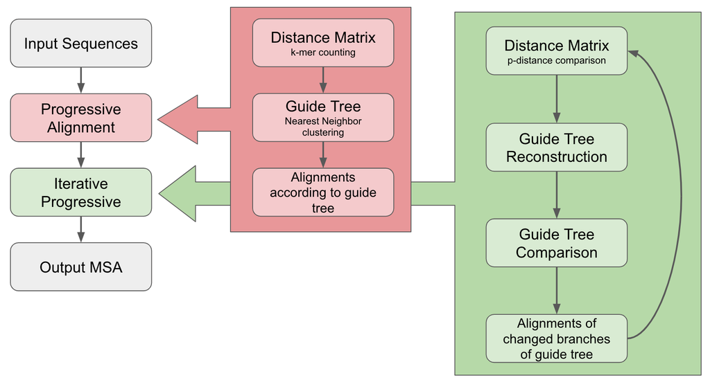

Flow chart describing the stages and intermediate steps of a YaMS alignment

### Pairwise Alignment

The fundamental process that drives a progressive alignment is a pairwise alignment (an alignment of two sequences). The pairwise alignment algorithm used in YaMS is an implementation of Needleman Wunsch modified in 3 ways. YaMS contains two implementations of modified Needleman-Wunsch algorithms. The first is Needleman-Wunsch with affine gap penalty which is used for sequence-sequence alignments. The second is a profile-profile Needleman-Wunsch with affine gap penalty used for profile-profile and profile-sequence alignments. The later is also capable of doing sequence-sequence alignments, but the former has better performance so is used when possible.

#### Needleman-Wunsch

The Needleman-Wunsch algorithm uses a scoring function that assigns a value to each possible pair of Nucleic Acids and a constant gap penalty.

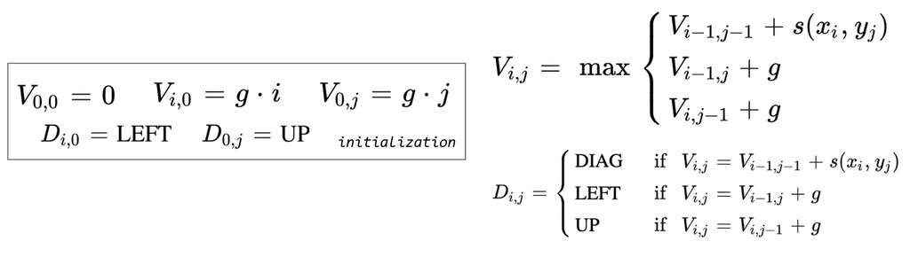

The basic Needleman-Wunsch algorithm: g = gap penalty, s(x,y) = score of aligning nucleic acids x and y. $^{[4]}$

Given two sequences x and y, where $x_i$, $y_i$ are the $i^{th}$ nucleic acids in each sequence, the algorithm works by computing a score matrix, V, and a direction matrix, D. $V_{i,j}$ is the best possible score of the alignment between the first i elements of x and the first j elements of y. Thus, the $i^{th}$ index in the first row and column represent aligning the $i^{th}$ element of one sequence to the first element of the other by inserting gaps at the beginning of one of the sequences. For this reason the first row and column are initialized to $i \times g$. For every other index, $V_{i,j}$ is a function of the index to the left, the index above and the index to the left diagonal. These three indices contain the best score for the three possible alignments for the previous nucleic acids in the sequence. The score of aligning $x_i$ and $y_j$ may be the score of aligning:

1. $x_i$ to a gap after $y_j$
2. $y_j$ to a gap after $x_i$
3. $x_i$ to $y_j$

The maximum of these options is chosen, and the choice is stored in the $D_{i,j}$ as an arrow referencing the index from which the maximum value was calculated. If there is more than one maximum of these three values, then there is more than one optimal alignment. When this occurs, YaMS just records one of the options in $D_{i,j}$ and ignores the other. The way this is chosen is undefined.

$V_{size(x),size(y)}$ contains the score of aligning the entire sequence. Using the arrows stored in the direction matrix, the optimal way to insert gaps into the sequence is encoded in the path from $D_{size(x),size(y)}$ to $D_{0,0}$. This path is a list of arrows. The path is iterated over from end to beginning. For a LEFT or RIGHT arrow, a gap is inserted in the corresponding location in the correct sequence. For a DIAG arrow, the corresponding locations in the sequences are matched or mismatched. The result is the alignment between the two sequences that yields the global optimal score.

#### Needleman-Wunsch with Affine Gap Penalty

Since insertion/deletion events can involve multiple sites, more accurate sequences can be obtained by distinguishing between an opening gap and a gap extension. YaMS by default gives the first gap in a sequence of 1 or more gaps a penalty of -9. Each other gap in the sequence receives a score of -1. Thus, given the opening gap penalty, d, and the gap extension penalty e, the total penalty for a sequence of n gaps is $d+(n-1) \times e$. The standard Needleman-Wunsch algorithm does not allow for affine gap penalty in the scoring function, so YaMS uses an adapted version of the algorithm.$^{[1,6]}$

The penalty for inserting a gap at $x_i$ or $y_j$ (ie. letting $D_{i,j}$ equal LEFT or RIGHT) is dependent on whether the optimal alignment of the sequences up to that point ends with a gap or not. This makes for 5 possible alignment choices rather than the 3 in the standard Needleman-Wunsch algorithm.

1. $x_i$ to a gap after $y_j$ given $x_{i-1}$ aligns to $y_j$
2. $x_i$ to a gap after $y_j$ given $x_{i-1}$ aligns to a gap
3. $y_j$ to a gap after $x_i$ given $y_{j-1}$ aligns to $x_i$
4. $y_j$ to a gap after $x_i$ given $y_{j-1}$ aligns to a gap
5. $x_i$ to $y_j$

Choices 1 and 3 involve inserting a gap after a match or mismatch, so the opening gap penalty should be used. Choices 2 and 4 involve inserting a gap after a gap, so the gap continuation penalty should be used. Finally, choice 5 should use the score $s(x_i,y_j)$.$^{[6]}$

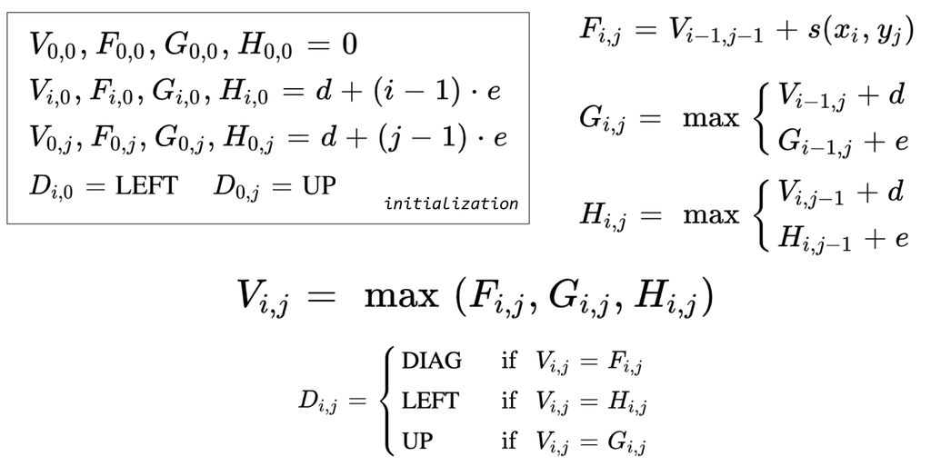

Needleman-Wunsch algorithm with affine gaps. $^{[6]}$

This is implemented through the use of 3 additional matrices F, G and H. $F_{i,j}$ is the score of choice 5. $G_{i,j}$ is the maximum of choices 1 and 2. $H_{i,j}$ is the maximum of choice 3 and 4. As such, matrix F contains the score yielded when a match is allowed, matrix G contains the scores when a gap is inserted in y, and matrix H contains the scores when a gap is inserted in x. The best of the five scores is stored in matrix V, and the choice made is stored in matrix D represented by an arrow. The optimal alignment is constructed from matrix D in the same way.

#### Profile-Profile Needleman-Wunsch with Affine Gap Penalty

To perform an MSA, it must be possible to perform an alignment between more than two sequences. The way YaMS does this is by doing profile alignments. A profile is a set of sequences that have already been aligned to each other. It is itself an MSA. The input to the profile-profile aligner is two profiles $x$ and $y$, where $x_i$ and $y_i$ are vectors containing the counts of each amino acid at the $i^{th}$ position of the profile’s sequences. These counts do not include gaps that may exist in some sequences at the $i^{th}$ position. $x_i^o$ and $y_i^o$ are the number of opening gaps at the $i^{th}$ position of the profiles while $x_i^e$ and $y_i^e$ are the number of gap extension at the $i^{th}$ position of the profiles. Additionally $x_i^{io}$ and $y_i^{io}$ are defined as the number of opening gaps that would exist in the profiles at the $i^{th}$ position if a gap where to be inserted at the $i^{th}$ position in every sequence in the profiles. Likewise, $x_i^{ie}$ and $y_i^{ie}$ are the number of gap extensions that would exist at the $i^{th}$ position in each profile under the same condition. Finally, $x^s$ and $y^s$ are the number of sequences included in each profile.

When a pofile-profile alignment inserts a gap in one of the profiles at the $i^{th}$ position, it inserts a gap in all of that profile’s sequences at the $i^{th}$ position. Unlike the sequence-sequence alignment algorithms described above, profile-profile alignment is not globally optimal. However, this restriction is applied in order to improve the computability of alignments. Finding an optimal alignment between n sequences of length m requires $O(m^n)$ time and space.$^{[3]}$ For all reasonably sized inputs, this is not acceptable. A single alignment between two profiles containing any number of sequences of length m requires only $O(m^2)$. Thus, profile-profile alignments are a necessary tradeoff between accuracy and performance.

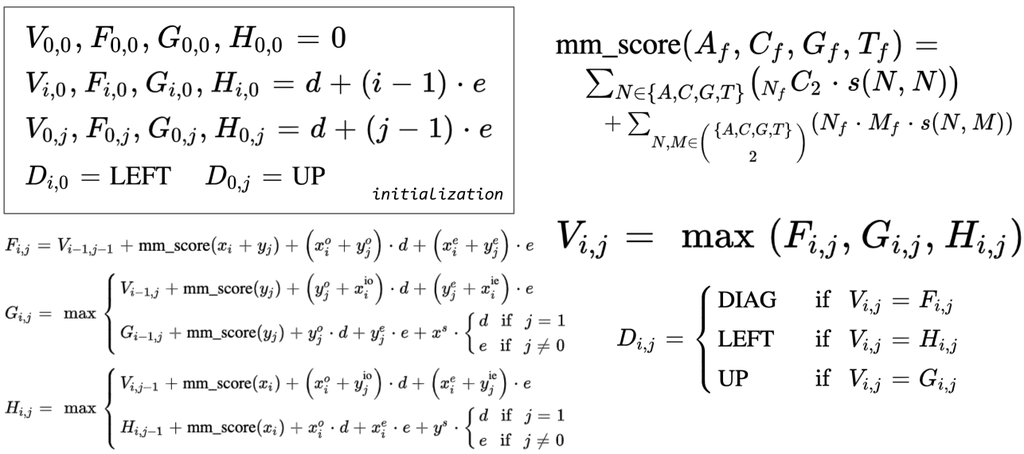

Profile-Profile Needleman-Wunsch algorithm with affine gaps

The two differences between a profile-profile and sequence-sequence alignment in YaMS are the way the match scores are calculated and the way gap types are identified. Since each profile may contain multiple nucleic acids at each index, the score of aligning two indices is calculated by taking the sum of scores of all pairs of nucleic acids that are aligned at the same index. The function $mm_score$ takes the counts of each amino acid and computes this score combinatorially. Much like the sequence-sequence version of Needleman-Wunsch, the profile-profile version builds 4 matrices that contain the maximum score of aligning every pair of nucleic acids under 5 different conditions. However, since the profile inputs are MSAs themselves, there may already be gaps in some sequences. Thus, inserting a gap at a given position in a profile may be inserting an open gap in some the sequences and inserting a gap extension in others. Additionally, aligning one index of a profile to an index in another may still result in gaps at those indices. This algorithm takes this into account by counting and weighing existing gaps as well as determining the types of gaps that would be inserted at each place in each sequence.

I could not find in depth descriptions of the profile-profile alignment algorithms used by existing sequence aligners, so it is possible that extending Needleman-Wunsch in this way is unique to YaMS.

#### Pairwise Alignment Optimizations

The vast majority of the time spent performing a YaMS MSA is spent performing pairwise sequence alignments, so most of the optimization work I performed was in this area. A single pairwise alignment consists of an initialization stage where all of the matrices are created and initialized, followed by a loop iterating over the indices of the matrices which consumes most of the time. The simplest optimization that gave a speedup of about 2 was to calculate and store all reusable values (ie. amino acid counts at each position) before the loop, rather than recalculating them for every position. The most complex and also most effective optimizations implemented in YaMS are cache locality optimizations.

Additionally, I chose to use PyPy instead of CPython to execute the program. CPython is the standard python interpreter, and is much more widespread and commonly used. However, without having to modify the code at all PyPy yields a speedup of about 10. It does this by performing JiT compilation on the most time intensive parts of a program. This reduces the overhead introduced by regular interpreters like CPython, and gives the benefits of micro-optimazations that are possible when compiling.

Between all of these optimizations, I was able to reduce the time for a single profile-profile optimization for sequences of length 2400 from about 25 minutes to 4 seconds. This is a significant and necessary improvement required if YaMS is to have any practical application.

### Progressive Alignment

The first stage of the alignment process is a progressive alignment. A pairwise distance matrix is computed using kmers distance approximation. Then a guide tree is built from this matrix using nearest neighbor clustering.$^{[5]}$ The guide tree is a binary tree used to determine the order in which sequences will be aligned. Each leaf node of the guide tree represents a single sequence while each internal node represents a profile. The profile represented by each internal node is an MSA of all the sequences at the leafs of the node’s respective subtree. The final MSA is represented by the profile at the root of the tree. The iteration of the guide tree is parallelized as follows.

- The initial pairs of sequences to align are computed by iterating the guide tree and recording all sibling leaf nodes.
- The main thread sends each initial pair on a pipe to to a pool of worker threads. It then waits for responses.
- A worker picks up a pair of sequences to align, performs the pairwise alignment, combines the pair to create a new profile, then returns the new profile to the main thread.
- The main thread receives the result of the alignment and stores it in the corresponding internal node in the tree.
- If the internal node’s sibling has already been aligned, the main thread dispatches the sibling pair to the worker threads.
- The alignment terminates once the tree’s root has been aligned.

The guide tree level parallelism is limited. For inputs containing a smaller number of sequences, some threads are likely to be starved early in the computation. As the part of the guide tree being worked on gets narrower there become fewer sister pairs. Additional limitations to the speedup that guide tree level parallelism can provide lies in the fact that sequence alignments are very memory heavy operations, meaning that on many computers, the memory access speed will become the bottleneck for the speed of the program rather than the number of cores executing alignments. From simple benchmarks on a single machine I estimate that running on 4 cores gives a speedup of about 2 only while none of the threads are starved.

### Iterative Progressive Alignment

The second stage of the alignment is an iterative progressive alignment aiming to resolve some of the errors introduced during the first progressive alignment. Kmers distance approximation is not a very good measure of distance due its simplicity, but it is one of the best available to use on unaligned sequences. However, with an approximate alignment available, it is possible to more accurately asses the pairwise distance between sequences. YaMS may use either pdistance or the inverse of the score depending on which flags are specified. Pdistance is the proportion of sites that differ. The inverse of the objective function score may also be used. I suspect from minimal testing that pdistance performs slightly better, so it is the default option.

A new distance matrix is created using the pairwise distance function of choice, and a new guide tree is constructed using nearest neighbor clustering on the distance matrix.$^{[5]}$ This new guide tree is then used for a new progressive alignment. However, since the new guide tree frequently has a similar structure to the old one, all nodes in the new guide tree with subtrees that have identical structure to that of a node in the old guide tree, need not be recomputed. Comparing the old guide tree to the new and copying over the alignments that have already been performed greatly reduces the number of alignments needing to be run.

This process is repeated until either a specified number of iterations have been completed or the number of subtrees that changed from one iteration to the last stops decreasing.$^{[2]}$

# Discussion

YaMS is a fully functional multiple sequence aligner capable of producing alignments that look pretty okay. From visual examination of the results, a human can pick out regions that should have some simple and apparently obvious modifications. I believe this to be a result of the flaws of pairwise alignment. Every MSA created via pairwise alignment contains at least one pair of sequences that were originally aligned to each other without regard for any of the other sequences in the MSA. Since there is no mechanism by which gaps may be relocated or removed in progressive alignment, once a gap is inserted in these early alignments, it will be a part a part of the result. MUSCLE uses a refinement stage that contains a mechanism through which gaps may be removed.$^{[2]}$ YaMS could possibly benefit extensively from the addition of a refinement stage.

# References

[1] Chatzou, M., Magus, C., & Chang, J. (2015). Multiple sequence alignment modeling: Methods and applications. Oxford Academic. doi: https://doi.org/10.1093/bib/bbv099

[2] Edgar, R. C. (2004). MUSCLE: A multiple sequence alignment method with reduced time and space complexity. BMC Bioinformatics, 5(1), 113. doi: 10.1186/1471-2105-5-113

[3] Generalized Dynamic Programming for Multiple Sequence Alignment. (n.d.). Retrieved May 10, 2021, from http://readiab.org/book/0.1.2/2/3

[4] Multiple sequence alignment. (2021, May 07). Retrieved May 10, 2021, from https://en.wikipedia.org/wiki/Multiple_sequence_alignment

[5] Neighbor joining. (2021, April 23). Retrieved May 10, 2021, from https://en.wikipedia.org/wiki/Neighbor_joining

[6] Sequence Alignment Lecture. (n.d.). Retrieved May 10, 2021, from https://web.stanford.edu/class/cs262/presentations/lecture2.pdf